# 국가별 음주 데이터 분석하기

```python
# -*- coding : utf-8 -*-

import pandas as pd
import numpy as np
import matplotlib.pyplot as plt

file_path = '../data/drinks.csv'
drinks = pd.read_csv(file_path)
print(drinks.info())
drinks.head(10)
```

```
<class 'pandas.core.frame.DataFrame'>
RangeIndex: 193 entries, 0 to 192
Data columns (total 6 columns):
country                         193 non-null object
beer_servings                   193 non-null int64
spirit_servings                 193 non-null int64
wine_servings                   193 non-null int64
total_litres_of_pure_alcohol    193 non-null float64
continent                       170 non-null object
dtypes: float64(1), int64(3), object(2)
memory usage: 9.1+ KB
None
```

|  | country | beer_servings | spirit_servings | wine_servings | total_litres_of_pure_alcohol | continent |
| --- | --- | --- | --- | --- | --- | --- |
| 0 | Afghanistan | 0 | 0 | 0 | 0.0 | AS |
| 1 | Albania | 89 | 132 | 54 | 4.9 | EU |
| 2 | Algeria | 25 | 0 | 14 | 0.7 | AF |
| 3 | Andorra | 245 | 138 | 312 | 12.4 | EU |
| 4 | Angola | 217 | 57 | 45 | 5.9 | AF |
| 5 | Antigua & Barbuda | 102 | 128 | 45 | 4.9 | NaN |
| 6 | Argentina | 193 | 25 | 221 | 8.3 | SA |
| 7 | Armenia | 21 | 179 | 11 | 3.8 | EU |
| 8 | Australia | 261 | 72 | 212 | 10.4 | OC |
| 9 | Austria | 279 | 75 | 191 | 9.7 | EU |

총 193개의 데이터가 있으며, 대륙정보에서는 23개의 결측값이 있다.  
피처는 다음과 같이 국가정보, 맥주소비량, spirit소비량 와인소비량, 총알콜 소비량, 대륙정보 6가지로 구성되어있다.

```python
drinks.describe()
```

|  | beer_servings | spirit_servings | wine_servings | total_litres_of_pure_alcohol |
| --- | --- | --- | --- | --- |
| count | 193.000000 | 193.000000 | 193.000000 | 193.000000 |
| mean | 106.160622 | 80.994819 | 49.450777 | 4.717098 |
| std | 101.143103 | 88.284312 | 79.697598 | 3.773298 |
| min | 0.000000 | 0.000000 | 0.000000 | 0.000000 |
| 25% | 20.000000 | 4.000000 | 1.000000 | 1.300000 |
| 50% | 76.000000 | 56.000000 | 8.000000 | 4.200000 |
| 75% | 188.000000 | 128.000000 | 59.000000 | 7.200000 |
| max | 376.000000 | 438.000000 | 370.000000 | 14.400000 |

피처간(와인과 맥주)의 상관 계수 구하기

```python
corr= drinks[['beer_servings', 'wine_servings']].corr(method='pearson')  #perason - 상관 계수 구하는 계산 방법 중 하나
print(corr)
```

```
               beer_servings  wine_servings
beer_servings       1.000000       0.527172
wine_servings       0.527172       1.000000
```

여러 피처의 상관 관계 분석

```python
cols = ['beer_servings', 'spirit_servings', 'wine_servings', 'total_litres_of_pure_alcohol'] #피처간의 상관계수 행렬
corr=drinks[cols].corr(method='pearson')
print(corr)
```

```
                              beer_servings  spirit_servings  wine_servings  \
beer_servings                      1.000000         0.458819       0.527172
spirit_servings                    0.458819         1.000000       0.194797
wine_servings                      0.527172         0.194797       1.000000
total_litres_of_pure_alcohol       0.835839         0.654968       0.667598

                              total_litres_of_pure_alcohol
beer_servings                                     0.835839
spirit_servings                                   0.654968
wine_servings                                     0.667598
total_litres_of_pure_alcohol                      1.000000
```

```python
import seaborn as sns
import matplotlib.pyplot as plt
```

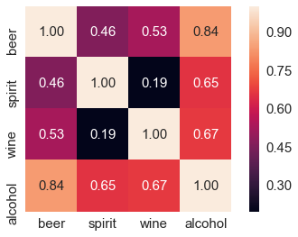

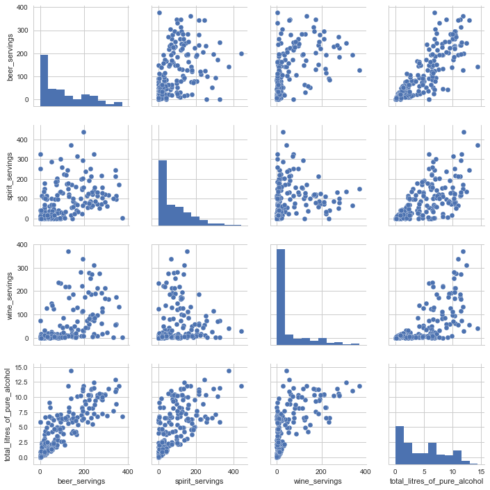

```python
cols_view=['beer','spirit','wine','alcohol'] #그래프 출력을 위한 cols 이름 축약
sns.set(font_scale=1.5)
hm = sns.heatmap(corr.values,
              cbar = True,
              annot = True,
              square = True,
              fmt = '.2f',
              annot_kws = {'size':15},
              yticklabels = cols_view,
              xticklabels = cols_view)
plt.tight_layout()
plt.show()

#시각화 라이브러리 이용한 피처 간의 산점도 그래프 출력
sns.set(style='whitegrid', context='notebook')
sns.pairplot(drinks[['beer_servings','spirit_servings','wine_servings','total_litres_of_pure_alcohol']])

plt.show()
```

```python
#결측 데이터 처리 - 기타 대륙으로 통합 -> OT
drinks['continent']=drinks['continent'].fillna('OT')
drinks.head(10)
```

|  | country | beer_servings | spirit_servings | wine_servings | total_litres_of_pure_alcohol | continent |
| --- | --- | --- | --- | --- | --- | --- |
| 0 | Afghanistan | 0 | 0 | 0 | 0.0 | AS |
| 1 | Albania | 89 | 132 | 54 | 4.9 | EU |
| 2 | Algeria | 25 | 0 | 14 | 0.7 | AF |
| 3 | Andorra | 245 | 138 | 312 | 12.4 | EU |
| 4 | Angola | 217 | 57 | 45 | 5.9 | AF |
| 5 | Antigua & Barbuda | 102 | 128 | 45 | 4.9 | OT |
| 6 | Argentina | 193 | 25 | 221 | 8.3 | SA |
| 7 | Armenia | 21 | 179 | 11 | 3.8 | EU |
| 8 | Australia | 261 | 72 | 212 | 10.4 | OC |
| 9 | Austria | 279 | 75 | 191 | 9.7 | EU |

파이차트로 시각화하기

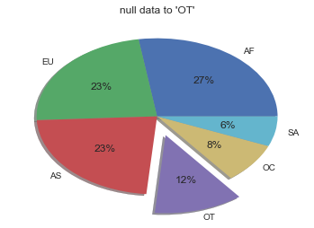

```python
labels=drinks['continent'].value_counts().index.tolist() #continent 피처의 value_counts() index리스트 = ['AF','EU','AS','OT','OC','SA']
fracs1=drinks['continent'].value_counts().values.tolist() #continent 피처의 value_counts() value리스트 = [53,45,44,23,16,12]
explode=(0,0,0,0.25,0,0)

#fracs1 = 파이차트에 표현되는 각 영역의 값
#plt = 이 값을 %로 변환하여 출력
#labels = 파이 차트에서 각 영역의 이름을 뜻함

plt.pie(fracs1, explode=explode, labels=labels, autopct='%.0f%%', shadow=True)
plt.title('null data to \'OT\'')
plt.show()
```

대륙별 spirit_servings의 평균, 최소, 최대, 합계 계산

```python
result = drinks.groupby('continent').spirit_servings.agg(['mean','min','max','sum'])
result.head()
```

| continent | mean | min | max | sum |
| --- | --- | --- | --- | --- |
| AF | 16.339623 | 0 | 152 | 866 |
| AS | 60.840909 | 0 | 326 | 2677 |
| EU | 132.555556 | 0 | 373 | 5965 |
| OC | 58.437500 | 0 | 254 | 935 |
| OT | 165.739130 | 68 | 438 | 3812 |

#### 전체 평균보다 많은 알콜을 섭취하는 대륙은?

```python
total_mean=drinks.total_litres_of_pure_alcohol.mean()
continent_mean=drinks.groupby('continent')['total_litres_of_pure_alcohol'].mean()
continent_over_mean=continent_mean[continent_mean>=total_mean]
print(continent_over_mean)
```

```
continent
EU    8.617778
OT    5.995652
SA    6.308333
Name: total_litres_of_pure_alcohol, dtype: float64
```

#### 평균 맥주 소비량이 가장 많은 대륙은?

```python
beer_continent=drinks.groupby('continent').beer_servings.mean().idxmax()
print(beer_continent)
```

```
EU
```

#### 대륙별 spirit 소비량의 평균, 최소, 최대, 합게 시각화하기

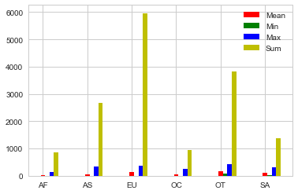

```python
n_groups=len(result.index)
means=result['mean'].tolist()
mins=result['min'].tolist()
maxs=result['max'].tolist()
sums=result['sum'].tolist()

index=np.arange(n_groups)
bar_width=0.1

rects1=plt.bar(index, means, bar_width, color='r', label='Mean')
rects2=plt.bar(index + bar_width, mins, bar_width, color='g', label='Min')
rects3=plt.bar(index + bar_width*2, maxs, bar_width, color='b', label='Max')
rects4=plt.bar(index + bar_width*3, sums, bar_width, color='y', label='Sum')

plt.xticks(index, result.index.tolist())
plt.legend()
plt.show()
```

#### 대륙별 알콜 총 소비량 시각화 하기

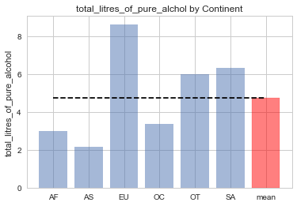

```python
continents = continent_mean.index.tolist()
continents.append('mean')
x_pos=np.arange(len(continents))
alcohol=continent_mean.tolist()
alcohol.append(total_mean)

bar_list=plt.bar(x_pos, alcohol, align='center', alpha=0.5)
bar_list[len(continents)-1].set_color('r')
plt.plot([0.,6], [total_mean, total_mean], "k--")
plt.xticks(x_pos, continents)

plt.ylabel('total_litres_of_pure_alcohol')
plt.title('total_litres_of_pure_alchol by Continent')

plt.show()
```

#### 대륙별 맥주 소비량 시각화 하기

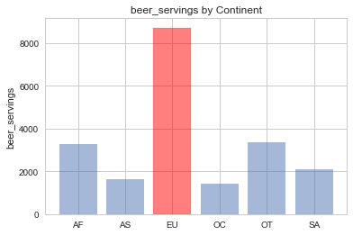

```python
beer_group = drinks.groupby('continent')['beer_servings'].sum()
continents=beer_group.index.tolist()
y_pos=np.arange(len(continents))
alcohol=beer_group.tolist()

bar_list=plt.bar(y_pos, alcohol, align='center', alpha=0.5)
bar_list[continents.index("EU")].set_color('r')
plt.xticks(y_pos,continents)

plt.ylabel('beer_servings')
plt.title('beer_servings by Continent')

plt.show()
```

#### 아프리카와 유럽 간의 맥주 소비량 차이 검정하기

```python
africa = drinks.loc[drinks['continent']=='AF']
europe = drinks.loc[drinks['continent']=='EU']

from scipy import stats
tTestResult = stats.ttest_ind(africa['beer_servings'], europe['beer_servings'])
tTestResultDiffVar=stats.ttest_ind(africa['beer_servings'],
                                  europe['beer_servings'], equal_var=False)

print("The t-statistic and p-value assuming equal variances is %.3f and %.3f" %tTestResult) #두 집단의 분산이 같은 경우
print("The t-statistic and p-value not assuming equal variances is %.3f and %.3f" %tTestResultDiffVar) #두 집단의 분산이 같지 않은 경우
```

```
The t-statistic and p-value assuming equal variances is -7.268 and 0.000
The t-statistic and p-value not assuming equal variances is -7.144 and 0.000
```

p-value가 모두 0.000이하이다.  
t-test의 귀무 가설은 '두 집단의 평균이 같다'이기 때문에 이를 기각한다.  
대립가설인 두 집단의 평균이 다르다를 채택했다.  
아프리카와 유럽 대륙간의 맥주 소비량 차이는 통계적으로 유의미하다.  
그러나 두집단의 데이터는 크기도 다르고, 각각의 크기 또한 크지 않기 때문에 실제로 통계적인 의미를가지는 검정이라고 보기엔 어려움이 있다.

#### 대한민국은 얼마나 술을 독하게 마시는 나라일까

```python
#total_servings 피처 생성
drinks['total_servings'] = drinks['beer_servings'] + drinks['wine_servings']+drinks['spirit_servings']

#술소비량 대비 알코올 비율 피처 생성
drinks['alcohol_rate'] = drinks['total_litres_of_pure_alcohol'] / drinks['total_servings']
drinks['alcohol_rate'] = drinks['alcohol_rate'].fillna(0)

#순위정보생성
country_with_rank=drinks[['country', 'alcohol_rate']]
country_with_rank = country_with_rank.sort_values(by=['alcohol_rate'], ascending=0)
country_with_rank.head(5)
```

|  | country | alcohol_rate |
| --- | --- | --- |
| 63 | Gambia | 0.266667 |
| 153 | Sierra Leone | 0.223333 |
| 124 | Nigeria | 0.185714 |
| 179 | Uganda | 0.153704 |
| 142 | Rwanda | 0.151111 |

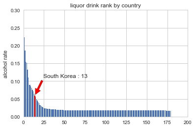

```python
#국가별 순위 정보 시각화
country_list=country_with_rank.country.tolist()
x_pos = np.arange(len(country_list))
rank=country_with_rank.alcohol_rate.tolist()

bar_list=plt.bar(x_pos,rank)
bar_list[country_list.index("South Korea")].set_color('r')
plt.ylabel('alcohol rate')
plt.title('liquor drink rank by country')
plt.axis([0, 200, 0, 0.3])

korea_rank = country_list.index("South Korea")
korea_alc_rate=country_with_rank[country_with_rank['country']=='South Korea']['alcohol_rate'].values[0]

plt.annotate('South Korea : ' + str(korea_rank - 1),
        xy=(korea_rank, korea_alc_rate),
        xytext=(korea_rank + 10, korea_alc_rate + 0.05),
        arrowprops=dict(facecolor='red', shrink=0.05))

plt.show()
```